# Simulated GARCH Process and Estimation

It is not often possible for GARCH proceeses to fit real world data in a perfect way. Therefore, it is important to test the estimation methods on simulated data (fictitious data constructed solely for the purpose of fitting our model of interest).

*Method used:* garchSim method from the fGarch package to create the data from our model.

**AR(3)-GARCH(2,2)**

$y_t = 0.5 y_{t-1} + 0.2y_{t-2} - 0.1y_{t-3} + u_t$

$u_t = \epsilon_t\sqrt{h_t}$

$\epsilon_t \sim N(0,1)$

$h_t = 0.001 + 0.3u^2_{t-1} + 0.2u^2_{t-2} + 0.2h_{t-1} + 0.1h_{t-2}$

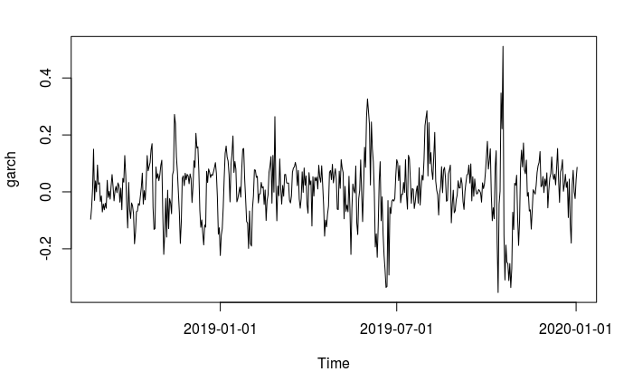

```r
library(fGarch)
library(forecast)
# generate simulated process
spec = garchSpec(model = list(omega = 0.001, ar = c(0.5, 0.2, -0.1),
alpha = c(0.3, 0.2),
beta = c(0.2, 0.1)))
process = garchSim(spec , n = 500)
plot(process)
```

**Main Findings:** There is persistence in the series although it is not trending not wandering arbitrarily. There are periods of high volatilty followed by periods of tranquillity.

**Autocorrelation Function:**

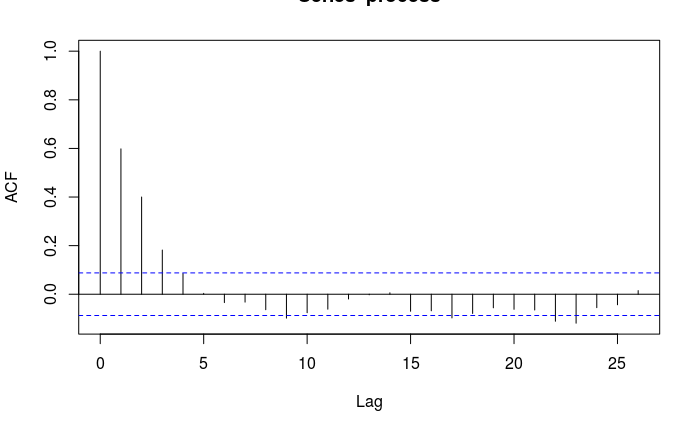

```r
acf(process)
```

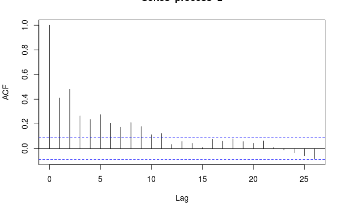

```r
acf(process^2)
```

Both show significant auto-correlations for several lags although the squared process has less persistence than the real world model has.

# Fitting Models

```r
model1 <- garchFit(formula ~ garch(3,0), data = process, trace = FALSE)
summary(model1)
```

```
Title:
 GARCH Modelling

Call:
 garchFit(formula = formula ~ garch(3, 0), data = process, trace = FALSE)

Mean and Variance Equation:
 data ~ garch(3, 0)
<environment: 0x556759a6e2f8>
 [data = process]

Conditional Distribution:
 norm

Coefficient(s):
       mu      omega     alpha1     alpha2     alpha3
0.0171056  0.0022735  0.5056104  0.2398247  0.1260718

Std. Errors:
 based on Hessian

Error Analysis:
        Estimate  Std. Error  t value Pr(>|t|)
mu     0.0171056   0.0037298    4.586 4.51e-06 ***
omega  0.0022735   0.0004193    5.422 5.89e-08 ***
alpha1 0.5056104   0.0935723    5.403 6.54e-08 ***
alpha2 0.2398247   0.0729394    3.288  0.00101 **
alpha3 0.1260718   0.0511367    2.465  0.01369 *
---
Signif. codes:  0 ‘***’ 0.001 ‘**’ 0.01 ‘*’ 0.05 ‘.’ 0.1 ‘ ’ 1

Log Likelihood:
 513.001    normalized:  1.026002

Description:
 Fri Jan  3 22:38:49 2020 by user:


Standardised Residuals Tests:
                                Statistic  p-Value
 Jarque-Bera Test   R    Chi^2  0.02200894 0.9890559
 Shapiro-Wilk Test  R    W      0.9978186  0.7715606
 Ljung-Box Test     R    Q(10)  144.7941   0
 Ljung-Box Test     R    Q(15)  148.9772   0
 Ljung-Box Test     R    Q(20)  150.0393   0
 Ljung-Box Test     R^2  Q(10)  6.956985   0.7294995
 Ljung-Box Test     R^2  Q(15)  13.53851   0.5607775
 Ljung-Box Test     R^2  Q(20)  19.38891   0.4966909
 LM Arch Test       R    TR^2   11.98794   0.4466489

Information Criterion Statistics:
      AIC       BIC       SIC      HQIC
-2.032004 -1.989858 -2.032202 -2.015466
```

While this model is sufficient to capture the time series properties of the squared residuals (GARCH effects), the levels of the residuals are still auto-correlated. The residuals test as normal.

## Fitting the Correct Model (AR(3)-GARCH(2,2))

```r
summary(model2)
```

[output not shown]

```
Title:
 GARCH Modelling

Call:
 garchFit(formula = formula ~ arma(3, 0) + garch(2, 2), data = process,
    trace = F)

Mean and Variance Equation:
 data ~ arma(3, 0) + garch(2, 2)
<environment: 0x556751556e28>
 [data = process]

Conditional Distribution:
 norm

Coefficient(s):
         mu          ar1          ar2          ar3        omega       alpha1       alpha2        beta1
 0.00646641   0.52282345   0.15941048  -0.12827644   0.00114857   0.28453939   0.20565854   0.00000001
      beta2
 0.35845376

Std. Errors:
 based on Hessian

Error Analysis:
         Estimate  Std. Error  t value Pr(>|t|)
mu      6.466e-03   2.870e-03    2.253 0.024261 *
ar1     5.228e-01   4.728e-02   11.059  < 2e-16 ***
ar2     1.594e-01   5.283e-02    3.017 0.002550 **
ar3    -1.283e-01   4.410e-02   -2.909 0.003626 **
omega   1.149e-03   2.148e-04    5.347 8.93e-08 ***
alpha1  2.845e-01   8.163e-02    3.486 0.000491 ***
alpha2  2.057e-01          NA       NA       NA
beta1   1.000e-08          NA       NA       NA
beta2   3.585e-01          NA       NA       NA
---
Signif. codes:  0 ‘***’ 0.001 ‘**’ 0.01 ‘*’ 0.05 ‘.’ 0.1 ‘ ’ 1

Log Likelihood:
 592.2288    normalized:  1.184458

Description:
 Fri Jan  3 22:42:30 2020 by user:


Standardised Residuals Tests:
                                Statistic p-Value
 Jarque-Bera Test   R    Chi^2  2.827493  0.2432303
 Shapiro-Wilk Test  R    W      0.9962396 0.2860351
 Ljung-Box Test     R    Q(10)  5.006198  0.8907636
 Ljung-Box Test     R    Q(15)  14.05173  0.5216098
 Ljung-Box Test     R    Q(20)  15.09361  0.7710265
 Ljung-Box Test     R^2  Q(10)  6.119008  0.8051676
 Ljung-Box Test     R^2  Q(15)  8.335906  0.9096108
 Ljung-Box Test     R^2  Q(20)  12.2305   0.907914
 LM Arch Test       R    TR^2   6.740368  0.8742834

Information Criterion Statistics:
      AIC       BIC       SIC      HQIC
-2.332915 -2.257052 -2.333548 -2.303147
```

In this case all diagnostic tests look good, i.e. normal and without autocorrelation in either level or square.

The **AR** coefficients are significant and almost within two standard deviations of their true values.

**GARCH** coefficients **BETAS** are nowhere near significant.

This often happens in situations where there are both AR and MA effects in either the conditional expectation or condition variance. Maybe a simpler model is able to capture the same time series properties more parsimoniously. There may exist many different but equivalent representations of the same process.

```r
model3 <- garchFit(formula ~ arma(3,0) + garch(2,0), data = process, trace = F)
summary(model3)
```

```
Title:
 GARCH Modelling

Call:
 garchFit(formula = formula ~ arma(3, 0) + garch(2, 0), data = process,
    trace = F)

Mean and Variance Equation:
 data ~ arma(3, 0) + garch(2, 0)
<environment: 0x5567589204a0>
 [data = process]

Conditional Distribution:
 norm

Coefficient(s):
        mu         ar1         ar2         ar3       omega      alpha1      alpha2
 0.0065923   0.5301238   0.1748819  -0.1265014   0.0028195   0.3491663   0.2586353

Std. Errors:
 based on Hessian

Error Analysis:
         Estimate  Std. Error  t value Pr(>|t|)
mu      0.0065923   0.0029228    2.255 0.024106 *
ar1     0.5301238   0.0476536   11.125  < 2e-16 ***
ar2     0.1748819   0.0521282    3.355 0.000794 ***
ar3    -0.1265014   0.0410143   -3.084 0.002040 **
omega   0.0028195   0.0003493    8.072 6.66e-16 ***
alpha1  0.3491663   0.0844369    4.135 3.55e-05 ***
alpha2  0.2586353   0.0649313    3.983 6.80e-05 ***
---
Signif. codes:  0 ‘***’ 0.001 ‘**’ 0.01 ‘*’ 0.05 ‘.’ 0.1 ‘ ’ 1

Log Likelihood:
 586.0189    normalized:  1.172038

Description:
 Fri Jan  3 22:56:38 2020 by user:


Standardised Residuals Tests:
                                Statistic p-Value
 Jarque-Bera Test   R    Chi^2  2.363739  0.3067049
 Shapiro-Wilk Test  R    W      0.995888  0.2177246
 Ljung-Box Test     R    Q(10)  4.25423   0.9351503
 Ljung-Box Test     R    Q(15)  13.19007  0.5876194
 Ljung-Box Test     R    Q(20)  14.10044  0.8253669
 Ljung-Box Test     R^2  Q(10)  13.64703  0.1897089
 Ljung-Box Test     R^2  Q(15)  17.1504   0.3099532
 Ljung-Box Test     R^2  Q(20)  21.2321   0.3835864
 LM Arch Test       R    TR^2   15.07784  0.2372072

Information Criterion Statistics:
      AIC       BIC       SIC      HQIC
-2.316075 -2.257071 -2.316460 -2.292922
```